# Prediction Assignment Writeup - Machine Learning

Using specialized devices it is possible to collect large amount of data about personal activity. In this project, Our goal is to use data from accelerometers on the belt, forearm, arm, and dumbell of 6 participants. The participants were asked to perform barbell lifts correctly and incorrectly in 5 different ways. There are 5 Classes that represent each performance: exactly according to the specification (Class A), throwing the elbows to the front (Class B), lifting the dumbbell only halfway (Class C), lowering the dumbbell only halfway (Class D) and throwing the hips to the front (Class E).

## Data Exploration

First we load the data. Besides NAs, instances of ‘“”’ and ‘#DIV/0!’ could be seen in the dataset. We treat all these cases as NAs.

```r
library(caret)
```

```r
library(corrplot)
library(randomForest)
library(kernlab)
library(lattice)
library(dplyr)
training_all <- read.csv("pml-training.csv",na.strings=c("NA","", "#DIV/0!"))
test_all <- read.csv("./pml-testing.csv", na.strings=c("NA","", "#DIV/0!"))
```

## Prepare the data

In this step, we first get rid of NA values and unwanted variables. Some variables don’t provide any significant value for predicting out target variable (classe). Hence, some of these variables have been removed from the dataset, i.e. “X”“,”user name“”, “raw timestamp part 1”, “raw timestamp part 2”, “cvtd timestamp”, “new window” and “num window”"

```r
training_cleaned <- training_all[, which(as.numeric(colSums(is.na(training_all)))==0)]
training_cleaned <- select(training_cleaned, -X, -user_name, -raw_timestamp_part_1, -raw_timestamp_part_2, -cvtd_timestamp, -new_window, -num_window)
```

## Slice the data to training and validation sets

We split the pml-training.csv data into two smaller sets. Training set (70%) and validation set (30%). We use the training set to build the model and validate it with the validation set.

```r
set.seed(345)
split_rate <- createDataPartition(training_cleaned$classe, p=0.70,list=FALSE)
training <- training_cleaned[split_rate,]
validation <- training_cleaned[-split_rate,]
```

## Selecting the right predictors

In this step, we look at the possibility of removing some of the highly correlated variables. We assumed the pair-wise absolute correlation cutoff of 70%. Setting aside variables that are strongly correlated may have substantial effect on the quality of the model. First we remove the target varialbe (classe) (non-numeric) from the training dataset. We used findCorrelation function of “caret” package. This function returns a vector of integers corresponding to columns to remove to reduce pair-wise correlations. As shown below, 20 variables have been detected with high correlation.

```r
test_correlations <- cor(training[,1:52])
high_correlations <- findCorrelation(test_correlations, cutoff = .70, verbose = FALSE)
cat("Number of highly correlated variables : ", length(high_correlations), "\n")
```

```
## Number of highly correlated variables :  20
```

total, there about 20 variables that are highly correlated. Next we remove all unwanted variables from the training and validation set.

```r
training <- training[, -high_correlations]
cat("Number of remaining variables including 'classe' :", length(training), "\n")
```

```
## Number of remaining variables including 'classe' : 33
```

Now we are left with about 32 variables plus the target variable (classe). The data is now ready for modeling.

## Build prediction model

We build a model using Random Forest method. As shown below, the OOB estimate of error rate is 1.16%.

```r
randomForest_Model <- randomForest(classe ~ ., data=training)
print(randomForest_Model)
```

```
##
## Call:
##  randomForest(formula = classe ~ ., data = training)
##                Type of random forest: classification
##                      Number of trees: 500
## No. of variables tried at each split: 5
##
##         OOB estimate of  error rate: 1.16%
## Confusion matrix:
##      A    B    C    D    E class.error
## A 3901    3    1    0    1 0.001280082
## B   27 2617   11    0    3 0.015425132
## C    0   27 2356   12    1 0.016694491
## D    0    0   55 2191    6 0.027087034
## E    1    0    1   10 2513 0.004752475
```

## Variable importance plot

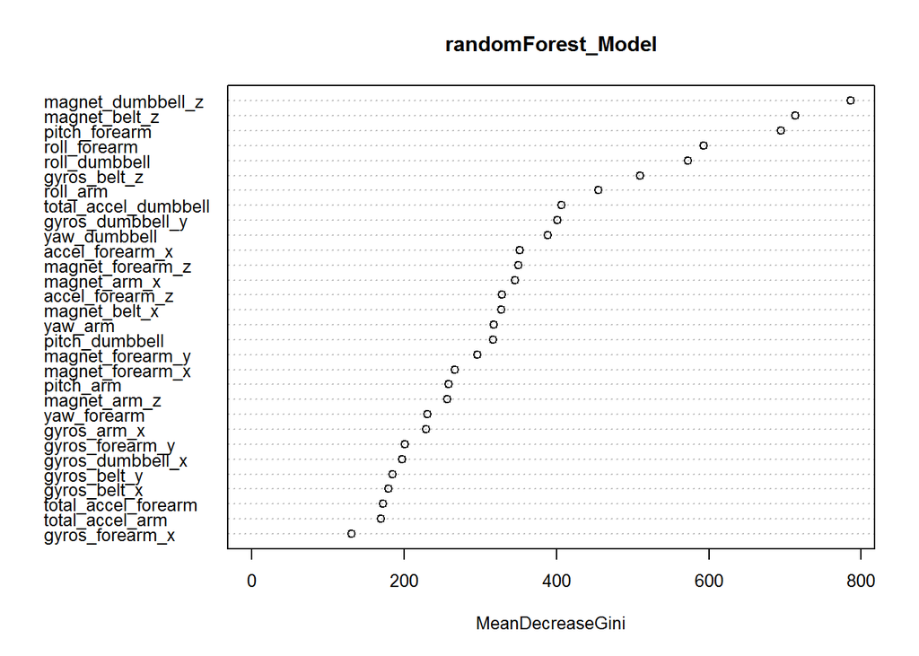

```r
varImpPlot(randomForest_Model, cex = 0.8)
```

```r
importance(randomForest_Model)
```

```
##                      MeanDecreaseGini
## gyros_belt_x                 179.0903
## gyros_belt_y                 184.9544
## gyros_belt_z                 509.2914
## magnet_belt_x                327.4904
## magnet_belt_z                713.3679
## roll_arm                     455.1945
## pitch_arm                    258.2322
## yaw_arm                      317.7722
## total_accel_arm              169.4830
## gyros_arm_x                  228.6969
## gyros_arm_z                  105.2887
## magnet_arm_x                 344.9015
## magnet_arm_z                 256.4505
## roll_dumbbell                572.8212
## pitch_dumbbell               317.0013
## yaw_dumbbell                 388.7398
## total_accel_dumbbell         406.7640
## gyros_dumbbell_x             197.5388
## gyros_dumbbell_y             401.0957
## gyros_dumbbell_z             127.1715
## magnet_dumbbell_z            786.2512
## roll_forearm                 592.8476
## pitch_forearm                694.8499
## yaw_forearm                  230.0415
## total_accel_forearm          172.2324
## gyros_forearm_x              130.4160
## gyros_forearm_y              200.6889
## accel_forearm_x              351.3641
## accel_forearm_z              328.0081
## magnet_forearm_x             266.1607
## magnet_forearm_y             295.8062
## magnet_forearm_z             349.4505
```

## Accuracy Level

After we build the model, we apply it to the validation set to see if our predictin accuracy is good enough. Below, we have predicted the ‘classe’ target variable using the validation set and compared the predicted ‘classe’ outputs with the actual ones. The accuracy rate is at 99% (0.9913), which is very descent.

```r
# there are 52 variables.

model_accuracy<- predict(randomForest_Model, validation)
print(confusionMatrix(model_accuracy, validation$classe))
```

```
## Confusion Matrix and Statistics
##
##           Reference
## Prediction    A    B    C    D    E
##          A 1672   10    0    0    0
##          B    1 1126   10    0    0
##          C    0    3 1015   20    0
##          D    0    0    1  944    5
##          E    1    0    0    0 1077
##
## Overall Statistics
##
##                Accuracy : 0.9913
##                  95% CI : (0.9886, 0.9935)
##     No Information Rate : 0.2845
##     P-Value [Acc > NIR] : < 2.2e-16
##
##                   Kappa : 0.989
##  Mcnemar's Test P-Value : NA
##
## Statistics by Class:
##
##                      Class: A Class: B Class: C Class: D Class: E
## Sensitivity            0.9988   0.9886   0.9893   0.9793   0.9954
## Specificity            0.9976   0.9977   0.9953   0.9988   0.9998
## Pos Pred Value         0.9941   0.9903   0.9778   0.9937   0.9991
## Neg Pred Value         0.9995   0.9973   0.9977   0.9959   0.9990
## Prevalence             0.2845   0.1935   0.1743   0.1638   0.1839
## Detection Rate         0.2841   0.1913   0.1725   0.1604   0.1830
## Detection Prevalence   0.2858   0.1932   0.1764   0.1614   0.1832
## Balanced Accuracy      0.9982   0.9931   0.9923   0.9890   0.9976
```

## 20 test runs

The test data has been retrieve from ‘pml-testing.csv file’.

```r
test <- predict(randomForest_Model, test_all)
answers <- as.vector(test)

pml_write_files = function(x) {
    n = length(x)
    for (i in 1:n) {
        filename = paste0("problem_id_", i, ".txt")
        write.table(x[i], file = filename, quote = FALSE, row.names = FALSE,
            col.names = FALSE)
    }
}

pml_write_files(answers)
```